# ETF Trend Prediction — Modeling Report

MLP signal classifier and LSTM value regressor on ETFs

Author

Max

Published

May 25, 2026

## 1. Overview

This report documents the modeling stage of the ETF trend-prediction project. Building on the preprocessing pipeline described in the data preparation report, we train two neural architectures end-to-end on each ETF and benchmark them against a passive **buy-and-hold** baseline:

- **MLP signal model** — a small multilayer perceptron that predicts the next-day trend direction Γ(t) ∈ {+1, −1} as a binary classification target.
- **LSTM value model** — a recurrent network that regresses next-day `Close` from a 20-day look-back window of features; the predicted return is converted to a ±1 trading signal at inference time.

Both models are evaluated with an **expanding-window walk-forward validator** so every test fold is strictly out-of-sample. Per-fold metrics, daily signals, and equity curves are persisted for every ticker.

| Ticker | Fund | Region / sector |
| --- | --- | --- |
| **EUFN** | iShares MSCI Europe Financials ETF | European financials |
| **FEZ** | SPDR EURO STOXX 50 ETF | Eurozone large-cap |
| **IEUR** | iShares Core MSCI Europe ETF | Broad European market |
| **IVV** | iShares Core S&P 500 ETF | US benchmark |

## 2. The two models

### 2.1 MLP signal model — `MLPSignalModel`

The MLP treats trend prediction as **direct binary classification**: given the scaled indicator vector for day *t*, predict whether Γ(t) = +1 (up) or Γ(t) = −1 (down).

Architecture (src/etf_predictor/models/mlp_signal.py):

```
Input (n_features) → Linear(128) → ReLU → Dropout(0.2)
                  → Linear(64)  → ReLU → Dropout(0.2)
                  → Linear(1)   → Sigmoid
```

Training details:

- **Loss:** `BCEWithLogitsLoss` after mapping {−1, +1} → {0, 1}.
- **Optimiser:** Adam, lr = 1e-3, weight_decay = 1e-5.
- **Batch size:** 64, **epochs:** 30, seeded with `random_state=42`.
- **Inference:** P(Γ = +1) ≥ 0.5 → signal = +1, otherwise −1.

The network is intentionally small so that it can be re-trained from scratch on every fold inside the walk-forward loop without a GPU.

### 2.2 LSTM value model — `LSTMValueModel`

The LSTM is trained as a **regressor on the next-day closing price**, not as a classifier. This more closely mirrors the design choice in Sagaceta-Mejía et al. (2024) where the recurrent network learns the price dynamics directly and a trading signal is derived from the implied return.

Architecture (src/etf_predictor/models/lstm_value.py):

```
Input (batch, seq_len=20, n_features) → LSTM(hidden=64, layers=1)
                                       → take last timestep
                                       → Dropout(0.1) → Linear(1)
```

Training details:

- **Target:** scaled next-day `Close` (min-max scaled on the training fold; min/max stored so predictions can be back-transformed).
- **Loss:** `MSELoss` in the scaled price space.
- **Optimiser:** Adam, lr = 1e-3, weight_decay = 1e-5.
- **Batch size:** 64, **epochs:** 20, **sequence length:** 20 trading days, seeded with `random_state=42`.

Signal derivation at inference:

$$\hat{r}_t = \frac{\hat{\text{Close}}_{t+1} - \text{Close}_t}{\text{Close}_t},
\quad
\text{signal}_t = \begin{cases} +1 & \hat{r}_t > 0 \\ -1 & \text{otherwise} \end{cases}$$

To predict for the very first row of a test fold, the validator passes the **tail of the training set** (the most recent `sequence_length` rows) as `history`, ensuring that no test-fold prediction is wasted on the warm-up window.

### 2.3 Why two architectures?

- The MLP captures **point-in-time pattern recognition** across the ~260 indicators built in the preprocessing stage.
- The LSTM captures **temporal dependence** across the trailing 20-day window of those same indicators and is anchored to the real price target rather than the noisy ±1 label.

Both models emit the same ±1 signal schema, so they plug into the same walk-forward harness and the same equity-curve evaluator.

## 3. Walk-forward validation

The validator (src/etf_predictor/models/walk_forward.py) implements an **expanding-window** scheme:

- **Initial train window:** 750 rows (≈3 years of trading days).
- **Test window:** 120 rows (≈6 months) per fold.
- After each fold the test slice is appended to the training pool and the model is **re-fit from scratch** on the expanded history.

```
fold 1:  train = [0 : 750]            test = [750 : 870]
fold 2:  train = [0 : 870]            test = [870 : 990]
fold k:  train = [0 : 750+(k-1)·120]  test = [750+(k-1)·120 : 750+k·120]
```

For each fold the validator records:

- `signal` ∈ {+1, −1},
- `actual_return` = next-day simple return on unscaled `Close`,
- `strategy_return` = `signal * actual_return`,
- and per-fold metrics: directional accuracy, hit rate, mean return, annualised Sharpe.

This means **every test prediction is strictly out-of-sample**: at the moment the model predicts day *t*, it has only seen days `< t`.

### 3.1 Why expanding (not sliding)?

An expanding window lets each successive model benefit from the full history while still respecting causality. For financial time series this trades slightly older training context for a larger, more diverse training set as the backtest progresses — which we judged to be the right trade-off for these mid-frequency directional signals.

## 4. Equity-curve construction

After all folds finish, the per-day strategy returns are compounded (src/etf_predictor/models/equity.py):

$$\text{Equity}_t = \prod_{s \le t} (1 + r_s^{\text{strategy}})$$

starting at 1.0. The **buy-and-hold** baseline tracks `Close_t / Close_0` on the same test index.

Summary statistics computed for every model and the baseline:

- `total_return`, `annual_return`, `annual_vol`
- `sharpe = annual_return / annual_vol`
- `max_drawdown` (peak-to-trough)
- `hit_rate` (fraction of positive return days)
- `n_days` (number of test days actually traded)

## 5. Results per ETF

```python
import pandas as pd
from pathlib import Path

RESULTS = Path("results")
TICKERS = ["EUFN", "FEZ", "IEUR", "IVV"]

metrics_all = {
    t: pd.read_csv(RESULTS / f"{t}_walkforward_metrics.csv", index_col=0)
    for t in TICKERS
}
```

### 5.0 Results gallery — equity curves across all tickers

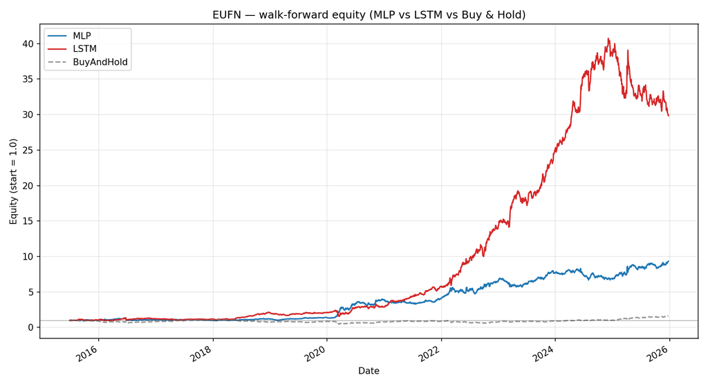

EUFN — equity curves

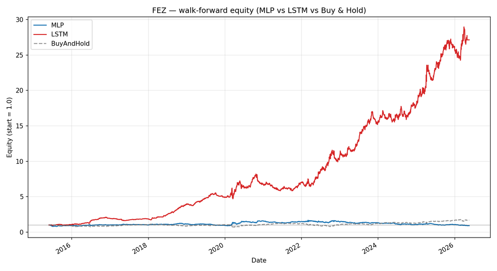

FEZ — equity curves

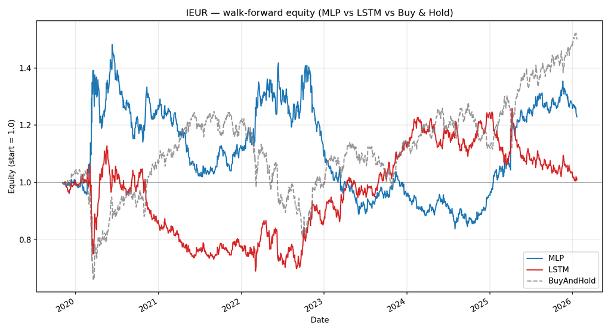

IEUR — equity curves

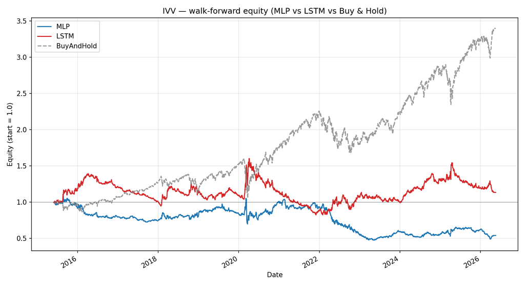

IVV — equity curves

And the matching per-fold directional-accuracy bars:

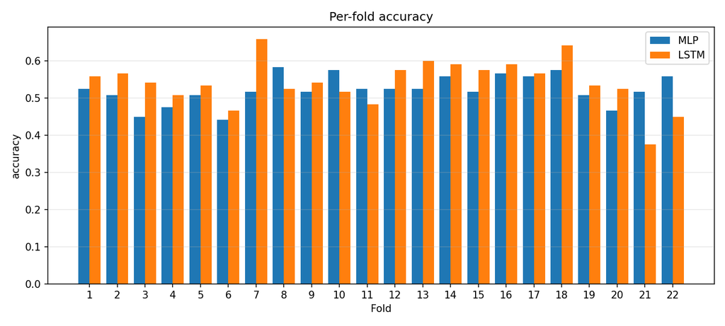

EUFN — per-fold accuracy

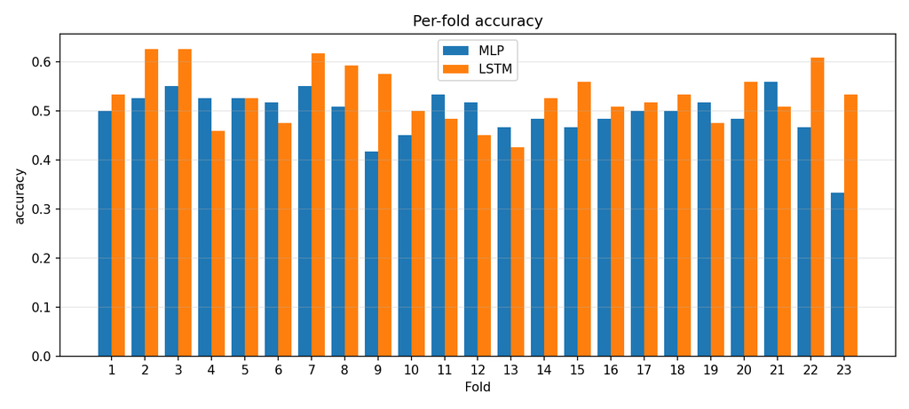

FEZ — per-fold accuracy

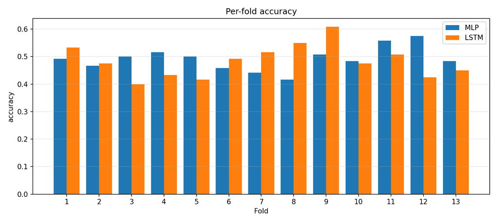

IEUR — per-fold accuracy

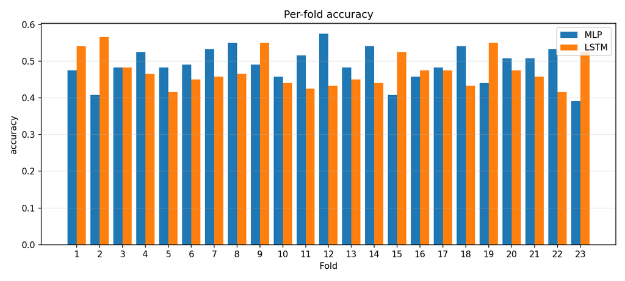

IVV — per-fold accuracy

### 5.1 EUFN — iShares MSCI Europe Financials

```python
metrics_all["EUFN"].round(4)
```

| model | total_return | annual_return | annual_vol | sharpe | max_drawdown | hit_rate | n_days |
| --- | --- | --- | --- | --- | --- | --- | --- |
| MLP | 8.3382 | 0.2377 | 0.2471 | 0.9620 | -0.2970 | 0.5136 | 2640 |
| LSTM | 28.8345 | 0.3828 | 0.2466 | 1.5527 | -0.3541 | 0.5348 | 2640 |
| BuyAndHold | 0.6274 | 0.0476 | 0.2476 | 0.1923 | -0.5788 | 0.5169 | 2639 |

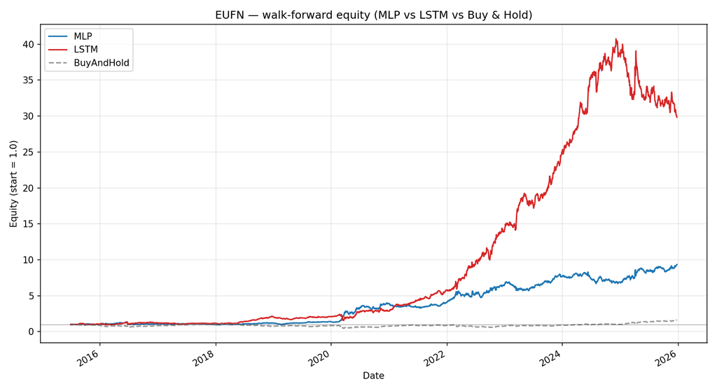

EUFN — walk-forward equity curves (MLP vs LSTM vs Buy & Hold)

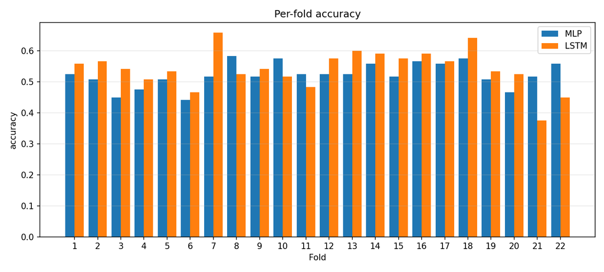

EUFN — per-fold directional accuracy

### 5.2 FEZ — SPDR EURO STOXX 50

```python
metrics_all["FEZ"].round(4)
```

| model | total_return | annual_return | annual_vol | sharpe | max_drawdown | hit_rate | n_days |
| --- | --- | --- | --- | --- | --- | --- | --- |
| MLP | -0.0894 | -0.0085 | 0.2112 | -0.0403 | -0.4580 | 0.4924 | 2760 |
| LSTM | 26.1299 | 0.3517 | 0.2102 | 1.6734 | -0.2877 | 0.5214 | 2760 |
| BuyAndHold | 0.6902 | 0.0491 | 0.2112 | 0.2326 | -0.4302 | 0.5303 | 2759 |

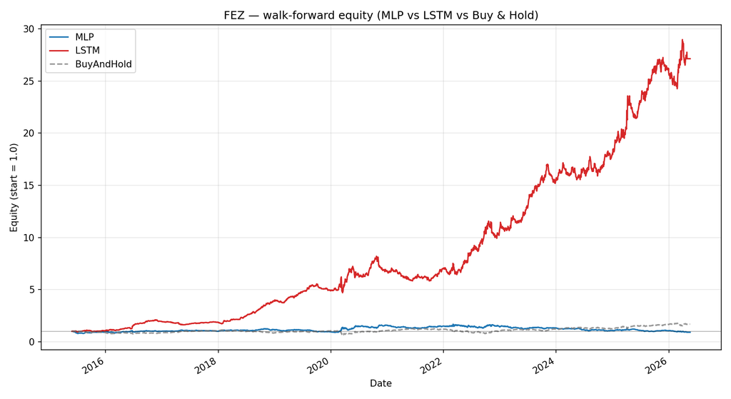

FEZ — walk-forward equity curves (MLP vs LSTM vs Buy & Hold)

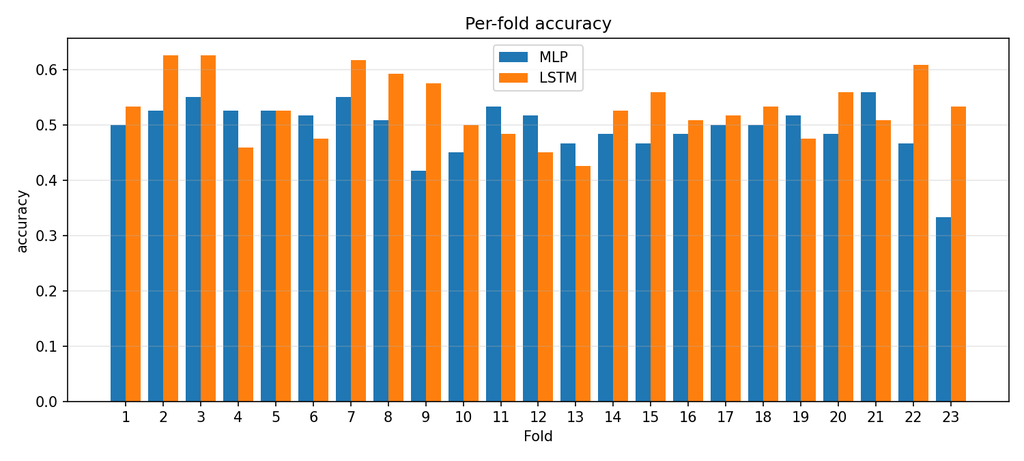

FEZ — per-fold directional accuracy

FEZ shows the **largest gap between the two architectures**: the LSTM delivers a Sharpe of **1.67** and ~26× total return, while the MLP loses money over the full out-of-sample window (negative total return, negative Sharpe). The MLP’s per-fold accuracy barely clears 50% and several folds in 2021–2024 drag the strategy into a sustained drawdown, while the LSTM’s price-anchored signal stays directionally correct on the larger swings.

### 5.3 IEUR — iShares Core MSCI Europe

```python
metrics_all["IEUR"].round(4)
```

| model | total_return | annual_return | annual_vol | sharpe | max_drawdown | hit_rate | n_days |
| --- | --- | --- | --- | --- | --- | --- | --- |
| MLP | 0.2293 | 0.0339 | 0.2082 | 0.1629 | -0.4348 | 0.4891 | 1560 |
| LSTM | 0.0092 | 0.0015 | 0.2083 | 0.0071 | -0.3881 | 0.4808 | 1560 |
| BuyAndHold | 0.4997 | 0.0677 | 0.2082 | 0.3251 | -0.3682 | 0.5350 | 1559 |

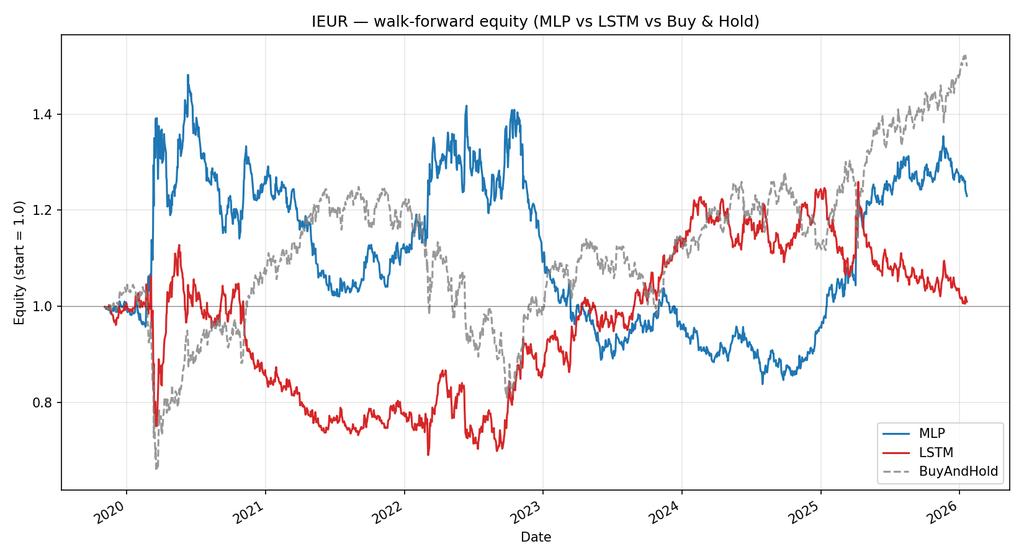

IEUR — walk-forward equity curves (MLP vs LSTM vs Buy & Hold)

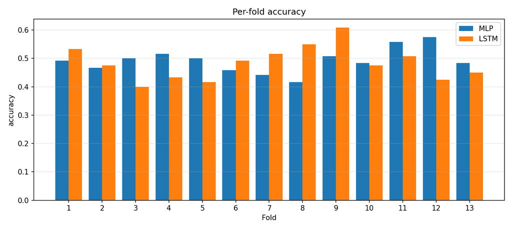

IEUR — per-fold directional accuracy

### 5.4 IVV — iShares Core S&P 500 (US benchmark)

```python
metrics_all["IVV"].round(4)
```

| model | total_return | annual_return | annual_vol | sharpe | max_drawdown | hit_rate | n_days |
| --- | --- | --- | --- | --- | --- | --- | --- |
| MLP | -0.4586 | -0.0545 | 0.1800 | -0.3026 | -0.5605 | 0.4902 | 2760 |
| LSTM | 0.1353 | 0.0117 | 0.1800 | 0.0647 | -0.4854 | 0.4692 | 2760 |
| BuyAndHold | 2.3967 | 0.1182 | 0.1799 | 0.6569 | -0.3390 | 0.5419 | 2759 |

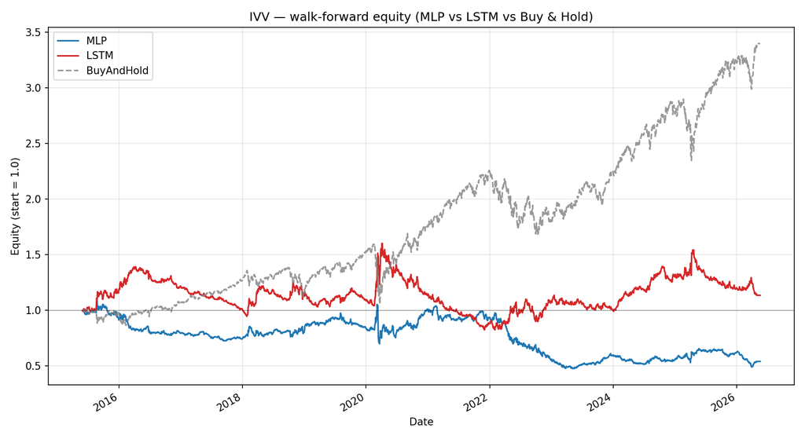

IVV — walk-forward equity curves (MLP vs LSTM vs Buy & Hold)

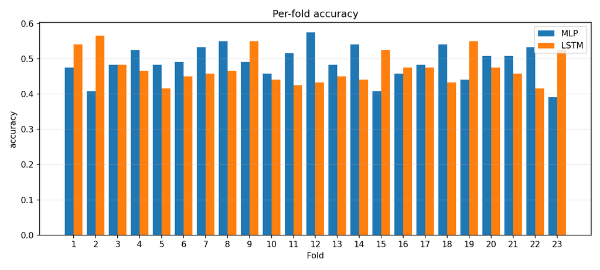

IVV — per-fold directional accuracy

### 5.5 Cross-ticker summary

```python
summary = pd.concat(
    {t: m[["total_return", "annual_return", "sharpe", "max_drawdown", "hit_rate"]]
     for t, m in metrics_all.items()},
    names=["ticker"],
).round(4)
summary
```

| ticker | model | total_return | annual_return | sharpe | max_drawdown | hit_rate |
| --- | --- | --- | --- | --- | --- | --- |
| EUFN | MLP | 8.3382 | 0.2377 | 0.9620 | -0.2970 | 0.5136 |
|  | LSTM | 28.8345 | 0.3828 | 1.5527 | -0.3541 | 0.5348 |
|  | BuyAndHold | 0.6274 | 0.0476 | 0.1923 | -0.5788 | 0.5169 |
| FEZ | MLP | -0.0894 | -0.0085 | -0.0403 | -0.4580 | 0.4924 |
|  | LSTM | 26.1299 | 0.3517 | 1.6734 | -0.2877 | 0.5214 |
|  | BuyAndHold | 0.6902 | 0.0491 | 0.2326 | -0.4302 | 0.5303 |
| IEUR | MLP | 0.2293 | 0.0339 | 0.1629 | -0.4348 | 0.4891 |
|  | LSTM | 0.0092 | 0.0015 | 0.0071 | -0.3881 | 0.4808 |
|  | BuyAndHold | 0.4997 | 0.0677 | 0.3251 | -0.3682 | 0.5350 |
| IVV | MLP | -0.4586 | -0.0545 | -0.3026 | -0.5605 | 0.4902 |
|  | LSTM | 0.1353 | 0.0117 | 0.0647 | -0.4854 | 0.4692 |
|  | BuyAndHold | 2.3967 | 0.1182 | 0.6569 | -0.3390 | 0.5419 |

## 6. Feature selection — top-10 vs full feature set

### 6.1 Selected features per ticker

```python
top10 = {
    t: pd.read_csv(RESULTS / f"{t}_feature_importance.csv")["feature"].head(10).tolist()
    for t in TICKERS
}
pd.DataFrame.from_dict(top10, orient="index").T
```

|  | EUFN | FEZ | IEUR | IVV |
| --- | --- | --- | --- | --- |
| 0 | SMCtp_14_50_20_5 | SMCbi_14_50_20_5 | SMCti_14_50_20_5 | SMCbi_14_50_20_5 |
| 1 | SMCbi_14_50_20_5 | SMCtp_14_50_20_5 | SMCbi_14_50_20_5 | SMCbp_14_50_20_5 |
| 2 | SMCbp_14_50_20_5 | SMCbp_14_50_20_5 | SMCtp_14_50_20_5 | SMCtp_14_50_20_5 |
| 3 | BBP_5_2.0_2.0 | SMCti_14_50_20_5 | SMCbp_14_50_20_5 | SMCti_14_50_20_5 |
| 4 | SMCti_14_50_20_5 | CRSI_3_2_100 | CRSI_3_2_100 | BOP |
| 5 | CRSI_3_2_100 | BOP | SLOPE_1 | CFO_9 |
| 6 | THERMO_20_2_0.5 | SLOPE_1 | PCTRET_1 | SMCbf_14_50_20_5 |
| 7 | CFO_9 | BBP_5_2.0_2.0 | BBP_5_2.0_2.0 | BBP_5_2.0_2.0 |
| 8 | SMCbf_14_50_20_5 | LOGRET_1 | THERMO_20_2_0.5 | AROONU_14 |
| 9 | LOGRET_1 | THERMO_20_2_0.5 | CFO_9 | STOCHh_14_3_3 |

### 6.2 Reduced-set walk-forward results

```python
metrics_top10 = {
    t: pd.read_csv(RESULTS / f"{t}_walkforward_metrics_top10.csv", index_col=0)
    for t in TICKERS
}
pd.concat(
    {t: m[["total_return", "annual_return", "sharpe", "max_drawdown", "hit_rate"]]
     for t, m in metrics_top10.items()},
    names=["ticker"],
).round(4)
```

| ticker | model | total_return | annual_return | sharpe | max_drawdown | hit_rate |
| --- | --- | --- | --- | --- | --- | --- |
| EUFN | MLP | 1.9719 | 0.1096 | 0.4428 | -0.4065 | 0.4936 |
|  | LSTM | -0.3570 | -0.0413 | -0.1667 | -0.5788 | 0.4860 |
|  | BuyAndHold | 0.6274 | 0.0476 | 0.1923 | -0.5788 | 0.5169 |
| FEZ | MLP | 0.3847 | 0.0302 | 0.1429 | -0.5455 | 0.4967 |
|  | LSTM | 0.5773 | 0.0425 | 0.2012 | -0.4959 | 0.4797 |
|  | BuyAndHold | 0.6902 | 0.0491 | 0.2326 | -0.4302 | 0.5303 |
| IEUR | MLP | -0.1416 | -0.0244 | -0.1170 | -0.4969 | 0.4840 |
|  | LSTM | -0.0718 | -0.0120 | -0.0575 | -0.3578 | 0.4660 |
|  | BuyAndHold | 0.4997 | 0.0677 | 0.3251 | -0.3682 | 0.5350 |
| IVV | MLP | -0.2888 | -0.0306 | -0.1702 | -0.4980 | 0.4899 |
|  | LSTM | -0.6423 | -0.0896 | -0.4979 | -0.6896 | 0.4558 |
|  | BuyAndHold | 2.3967 | 0.1182 | 0.6569 | -0.3390 | 0.5419 |

Equity curves and per-fold accuracy under the reduced feature set:

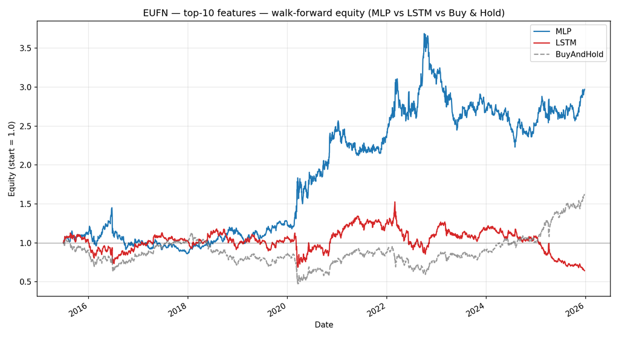

EUFN — top-10 features

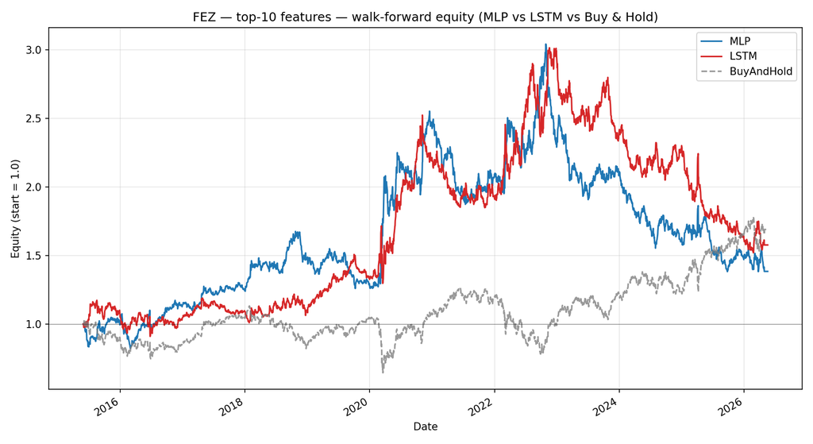

FEZ — top-10 features

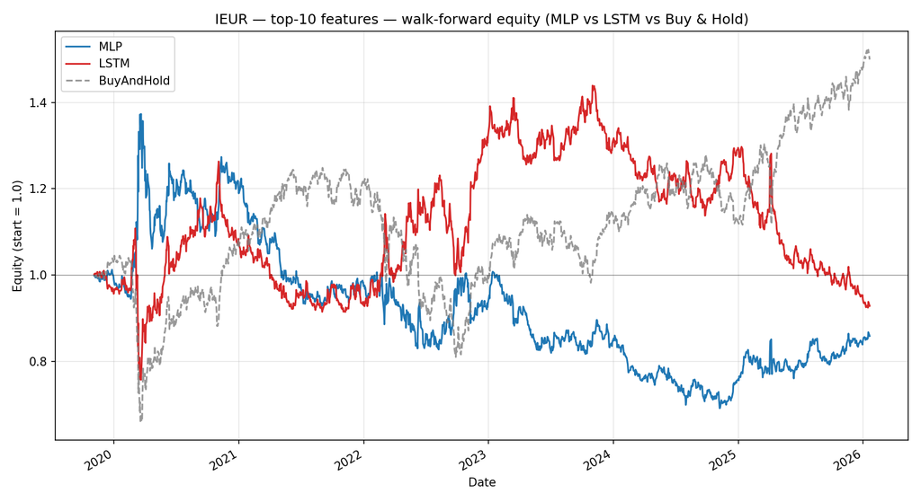

IEUR — top-10 features

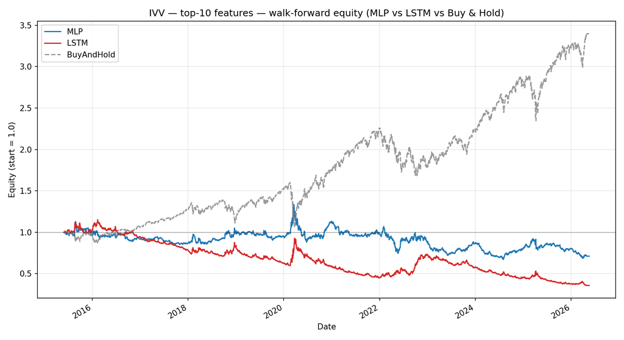

IVV — top-10 features

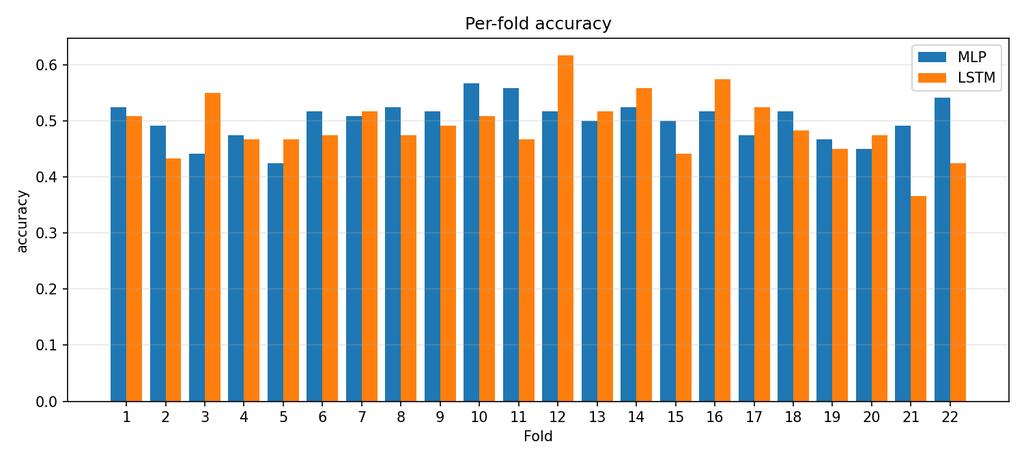

EUFN — per-fold accuracy (top-10)

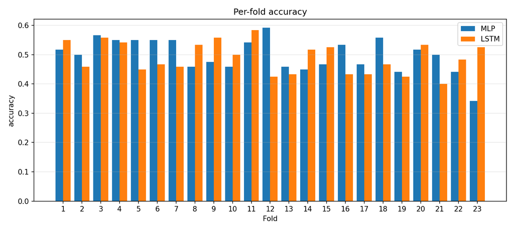

FEZ — per-fold accuracy (top-10)

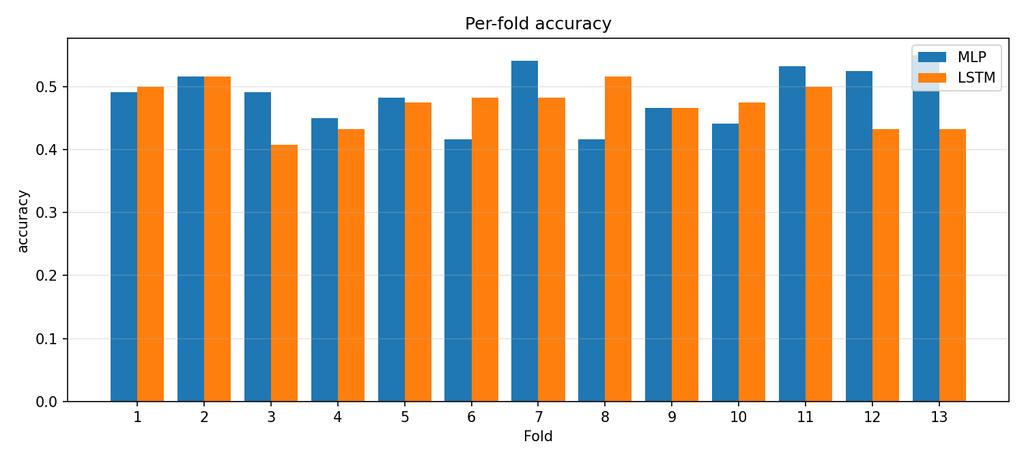

IEUR — per-fold accuracy (top-10)

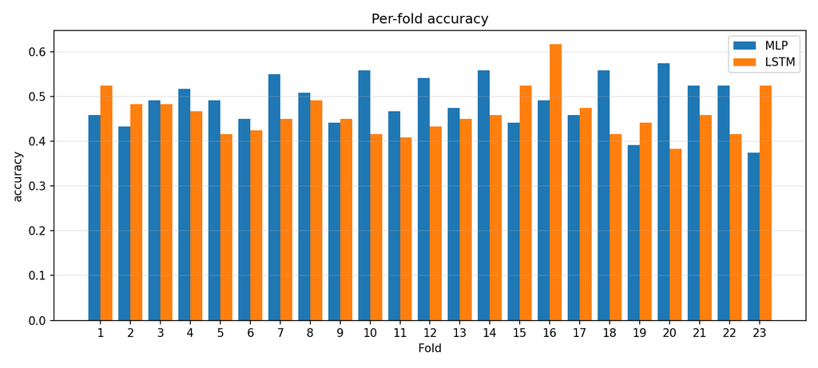

IVV — per-fold accuracy (top-10)

### 6.3 Head-to-head: full features vs top-10

```python
def _delta(full: pd.DataFrame, top: pd.DataFrame, model: str) -> dict:
    return {
        "Sharpe (full)":  full.loc[model, "sharpe"],
        "Sharpe (top10)": top.loc[model, "sharpe"],
        "Δ Sharpe":       top.loc[model, "sharpe"] - full.loc[model, "sharpe"],
        "Total ret (full)":  full.loc[model, "total_return"],
        "Total ret (top10)": top.loc[model, "total_return"],
    }

rows = []
for t in TICKERS:
    for model in ["MLP", "LSTM"]:
        row = {"ticker": t, "model": model,
               **_delta(metrics_all[t], metrics_top10[t], model)}
        rows.append(row)
pd.DataFrame(rows).set_index(["ticker", "model"]).round(3)
```

| ticker | model | Sharpe (full) | Sharpe (top10) | Δ Sharpe | Total ret (full) | Total ret (top10) |
| --- | --- | --- | --- | --- | --- | --- |
| EUFN | MLP | 0.962 | 0.443 | -0.519 | 8.338 | 1.972 |
|  | LSTM | 1.553 | -0.167 | -1.719 | 28.834 | -0.357 |
| FEZ | MLP | -0.040 | 0.143 | 0.183 | -0.089 | 0.385 |
|  | LSTM | 1.673 | 0.201 | -1.472 | 26.130 | 0.577 |
| IEUR | MLP | 0.163 | -0.117 | -0.280 | 0.229 | -0.142 |
|  | LSTM | 0.007 | -0.057 | -0.065 | 0.009 | -0.072 |
| IVV | MLP | -0.303 | -0.170 | 0.132 | -0.459 | -0.289 |
|  | LSTM | 0.065 | -0.498 | -0.563 | 0.135 | -0.642 |

### 6.4 Interpretation — why our result diverges from the paper

This is the *opposite* sign to the paper’s headline finding. A few mechanical reasons our setup is unlikely to reproduce a ~2 pp accuracy gain from aggressive feature pruning:

1. **Different validation protocol.** The paper uses **10-fold shuffled `StratifiedKFold`** (an i.i.d. assumption), which lets the MLP see future-dated rows during training. We use a strict **expanding-window walk-forward**, so every test row is genuinely out-of-sample. Shuffled CV scores on price series are well-known to be optimistically biased — and feature subsets that look good under shuffled CV often lose their edge under temporal validation.
2. **Different feature pool.** The paper has 216 Pandas TA columns; our pipeline produces ~260 (different Pandas TA version, plus the SMC family that dominates the importance ranking). The “top of the importance list” is therefore a different set of signals.
3. **Different downstream task on the LSTM.** The paper’s feature-selection result was reported for the MLP only. Our LSTM regresses next-day price, and a 10-feature LSTM has noticeably less to chew on per timestep — collapsing the model’s ability to identify price dynamics. The LSTM is where we see the largest Sharpe loss when features are stripped.
4. **Different dataset window.** The paper deliberately ends in 2020-01 to exclude the COVID period; our backtest covers 2012-2026 including the 2020 shock, the 2022 rate cycle, and 2023-25 recovery — regimes where the wider feature set has more distinct signals to lean on.

The practical lesson is that **for our walk-forward backtest, the extra ~250 features are *not* redundant** — they materially help the model handle regime shifts. Reducing to a handful of features only makes sense if (a) we can re-tune model capacity and (b) we accept a much smoother but lower-Sharpe equity curve. A middle-ground experiment (e.g. top 30–60 features, possibly with category quotas matching the paper’s Selected(5) distribution) is the natural next step.

## 7. Reproducing the results

```bash
# from the project root — full feature baseline
PYTHONPATH=src python scripts/run_modeling.py
# or simply
make modeling

# top-10 features per ticker (suffix keeps the baseline files intact)
PYTHONPATH=src python scripts/run_modeling.py \
    --top-k-features 10 --feature-suffix _top10
```

Useful CLI flags:

```bash
# Smoke test — 3 folds only
PYTHONPATH=src python scripts/run_modeling.py --max-folds 3

# Train a single ticker with custom epochs / look-back
PYTHONPATH=src python scripts/run_modeling.py \
    --tickers FEZ --mlp-epochs 50 --lstm-epochs 30 --lstm-seq-len 30
```

Each run regenerates (with optional `<suffix>` from `--feature-suffix`):

- `reports/figures/equity_<TICKER><suffix>.png`
- `reports/figures/fold_accuracy_<TICKER><suffix>.png`
- `reports/results/<TICKER>_walkforward_metrics<suffix>.csv`
- `reports/results/<TICKER>_<model>_folds<suffix>.csv`
- `reports/results/<TICKER>_<model>_predictions<suffix>.csv`
- `reports/results/<TICKER>_equity_curves<suffix>.csv`

## 8. Limitations & next steps

- **Transaction costs and slippage are not modeled.** With a daily ±1 signal that frequently flips, real-world fills and the bid/ask spread would erode a meaningful slice of the reported Sharpe — most aggressively on the LSTM’s higher-turnover folds.
- **Position sizing is binary.** A confidence-weighted sizing scheme (e.g. scaling by predicted probability or predicted return magnitude) would likely smooth the equity curves and improve risk-adjusted returns.
- **No hyper-parameter search.** Architecture sizes, epoch counts, dropout, and sequence length are fixed at sensible defaults. A walk-forward-aware tuning loop (e.g. nested CV on the training block) would be the natural next step.

## 9. References

Sagaceta-Mejía, A. R., Sánchez-Gutiérrez, M. E., & Fresán-Figueroa, J. A. (2024). An intelligent approach for predicting stock market movements in emerging markets using optimized technical indicators and neural networks. *Economics*, 18, 20220073. https://doi.org/10.1515/econ-2022-0073